# Derivatives and Partial Derivatives with grad

W. Bauer

03/03/2015

1. The point of this unit is to introduce derivatives and partial derivatives in a general setting, and to introduce numerical differentiation with `grad`.
   - Previously, we noted the simplest example of a derivative is the slope of a line.
   - We also noted that the closer you look at a smooth curve, the more it looks like a line. This allows us to assign a slope at any point on a smooth curve by taking a limit.

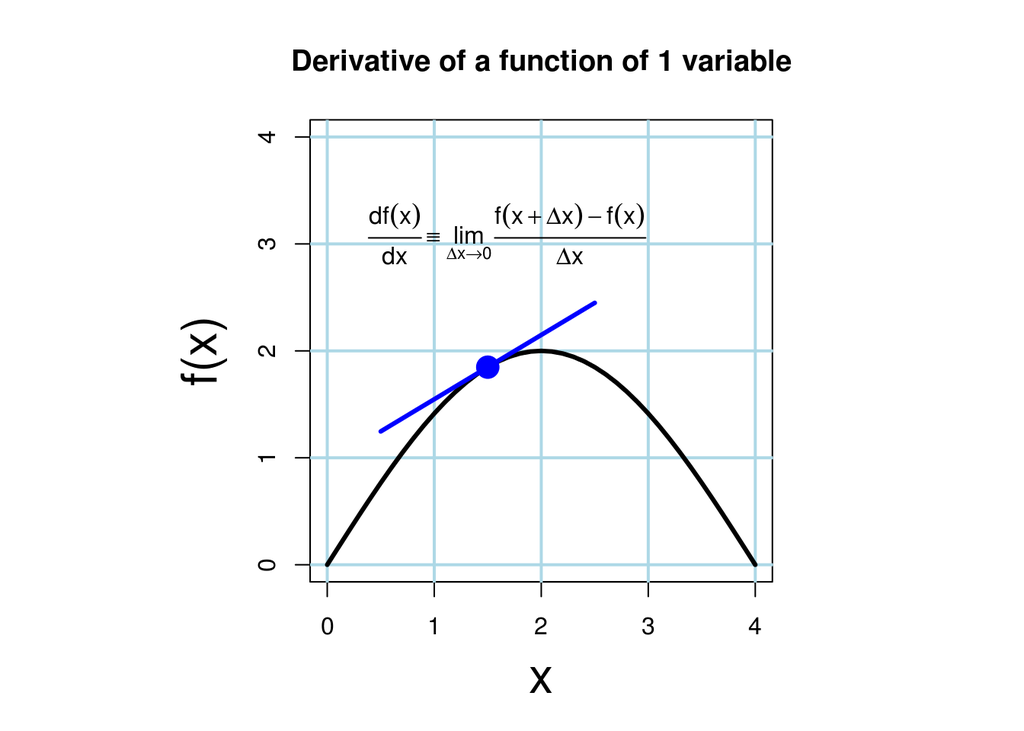

2. Numerical derivatives with `grad`
   - Derivatives of many functions can be found analytically. The figure shows how to find the derivative of $x^2$ using only the definition and elementary algebra.

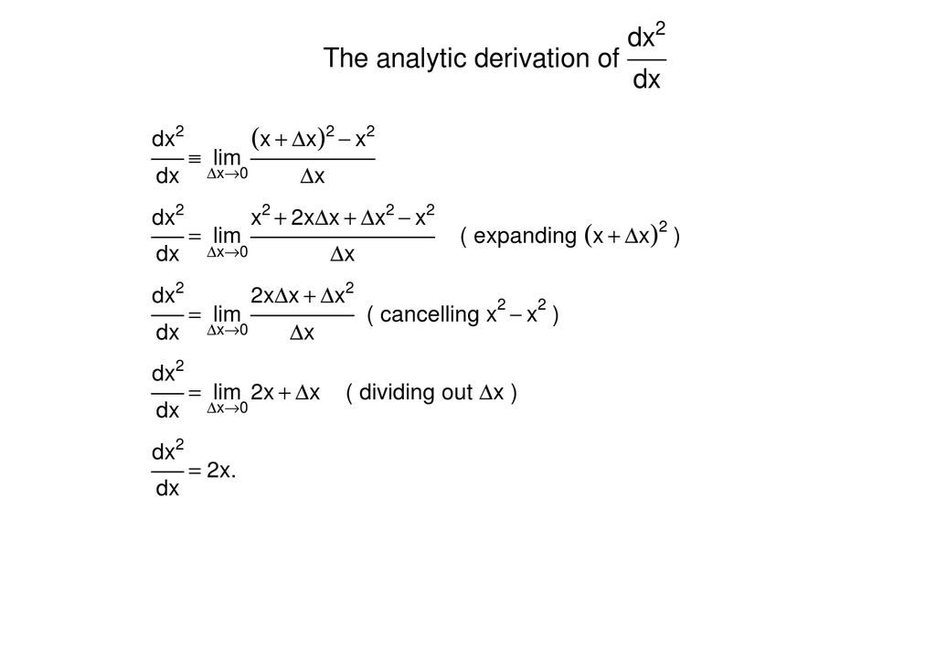

   - Here, however, we will focus on estimating derivatives numerically, using the function, `grad`, in package numDiff. (The name is a short form of “gradient,” a term which will be explained later.)
   - `grad` takes two arguments, a function and a point at which the derivative of the function is to be estimated.
   - For instance `grad(function(x)x^2, 1)` will estmate the derivative of `x^2` at x=1. You know from the analytic derivation that this should be 2.
   - In the example, grad’s first argument, `function(x)x^2` is an R function which takes one numerical argument and returns the value `x^2` at the point `x` represented by that argument.
   - Using common functions such as cos, sin, exp, log, 1/x, have students compare their numerical and analytic derivatives. The follow code illustrates how that might be done. Note that `grad` is vectorized for functions of 1 variable but has nothing analogous for functions of several. I think that is confusing, but vectorization comes in handy here.

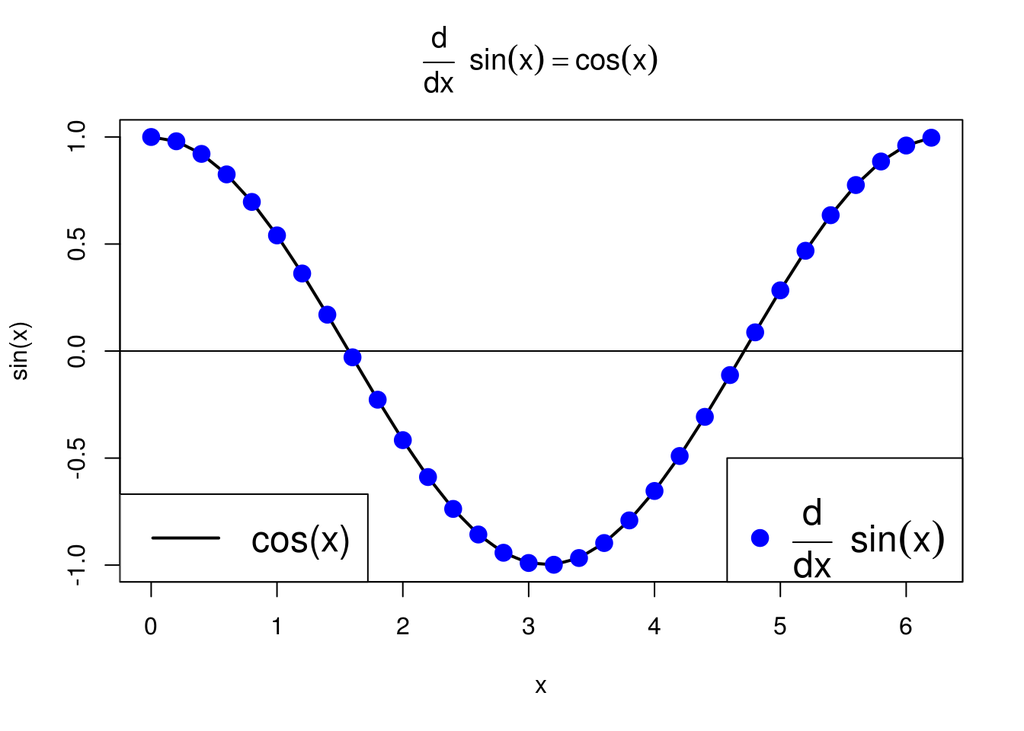

   ```r
   # Show that the derivative of sin is cos.
   x <- seq(0, 2*pi, by=.2)
   # swirl does this
   plot(x, cos(x), type='l', lwd=2, xlab="x", ylab="sin(x)", main=expression(over(d, d*x)~~sin(x) == cos(x)))
   abline(h=0)
   legend('bottomleft', "cos(x)", lwd=2, cex=1.5)
   legend('bottomright', expression(over(d, d*x)~~sin(x)), pch=19, col="blue", cex=1.5)
   # student does this
   deriv <- grad(sin, x)
   points(x, deriv, pch=19, col="blue", cex=1.5)
   ```

3. Gradients on Maunga Whau
   - In general, we may have functions of several variables, such as this topographic map of Maunga Whau volcano. Here f(x, y) is altitude, x is northward distance from a reference point, and y is westward distance from the reference point.

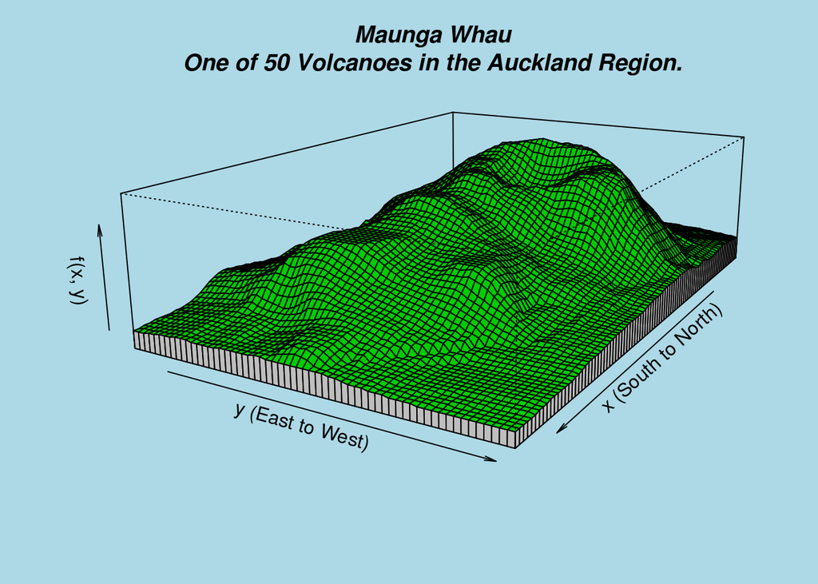

   - For this case there are *partial derivatives* in which estimate the slope with respect to one variable while holding the others constant.

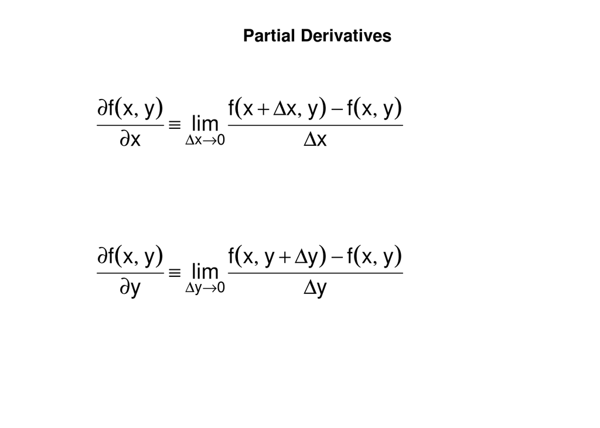

   - At a point on Maunga Whau, the partial derivatives represent slopes in the x and y directions. In the case pictured, the partial derivatives are indicated by the slopes of the lines labeled x and y.

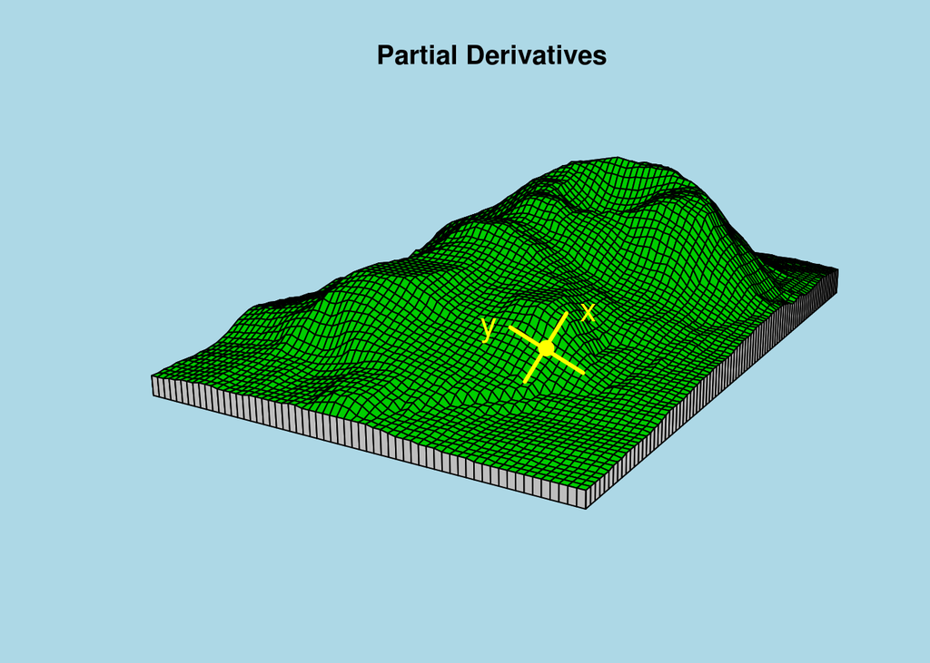

   - The *gradient* of a function of more than one variable is a vector of its partial deriviatives. It is usually symbolized by a nabla (upside down triangle,) as illustrated in the figure.

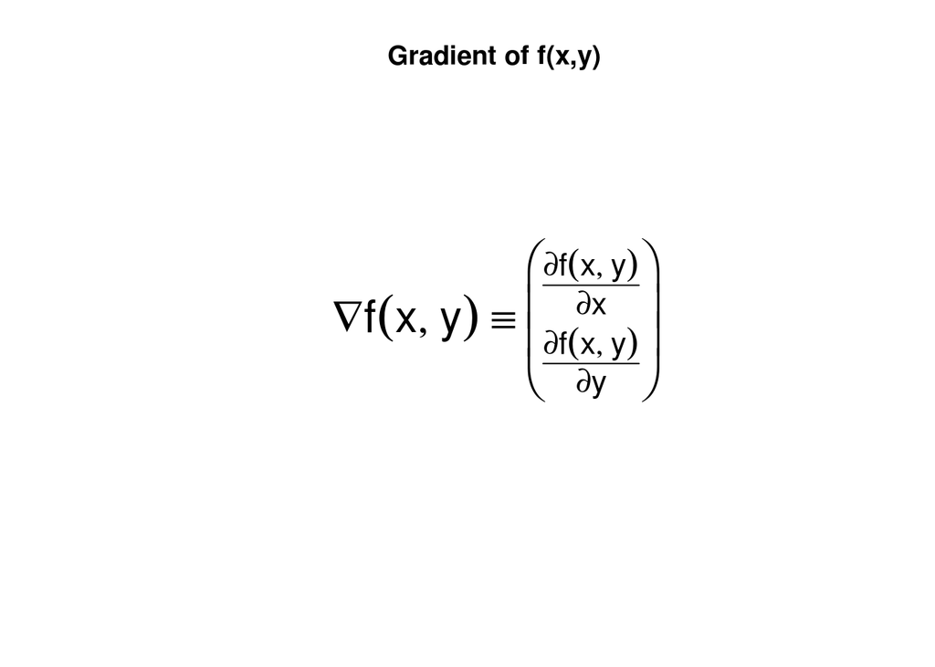

   - It can be shown that the gradient indicates the magnitude and direction of steepest ascent. The gradient at a point on Maunga Whau is shown here.

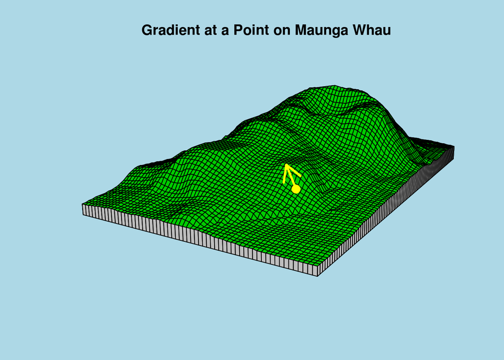

   - Like derivatives, gradients can be estimated using the function, `grad`, in package numDiff.
   - As before, `grad` takes two arguments, a function and a point at which the gradient of the function is to be estimated. But in this case, the “point” is a vector.
   - If the function depends on two variables, the vector has length two, if three length three, and so on.
   - We’ve written `mw(point)` which gives the altitude of Maunga Whau as a function of point coordinates. (Actually it gives twice the altitude, since that’s the way z is calibrated.)
   - Illustrate the use of `mw` by finding the altitude at the pictured points.

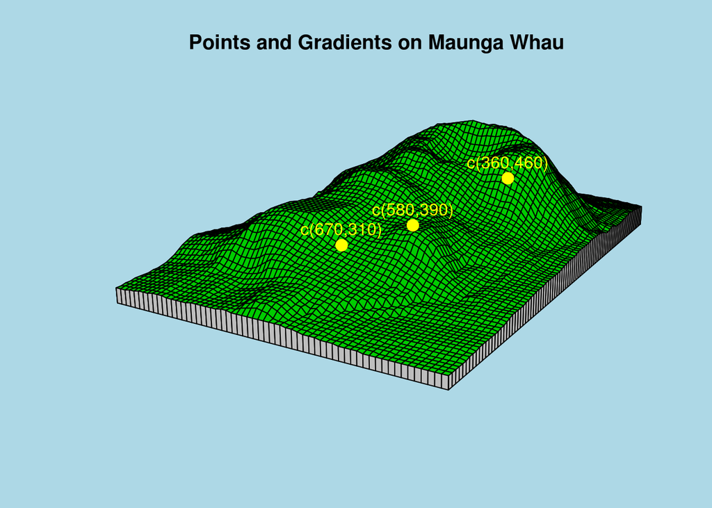

   ```r
   mw(c(670, 310))
   ```

   ```
   ## [1] 258
   ```

   ```r
   mw(c(580, 390))
   ```

   ```
   ## [1] 280
   ```

   ```r
   mw(c(360, 460))
   ```

   ```
   ## [1] 322
   ```

   - Illustrate `grad` by finding the gradient at those same points

   ```r
   grad(mw,c(670, 310))
   ```

   ```
   ## [1] -73.04468 -78.64506
   ```

   ```r
   grad(mw,c(580, 390))
   ```

   ```
   ## [1] 0 0
   ```

   ```r
   grad(mw,c(360, 460))
   ```

   ```
   ## [1]  66.55686 105.26291
   ```

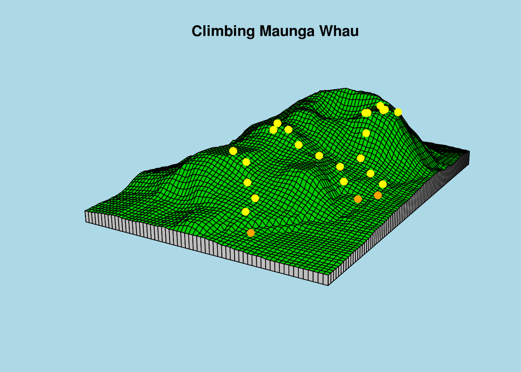